# Homework

Yunzhe Li

5/6/2019

```r
knitr::opts_chunk$set(echo = TRUE)
library(knitr)
library(LearnBayes)
```

# 6.7.2

Model checking: in Excersice 2.13, the counts of airline fatalitie in 1976-1985 were fitted to four different Poisson models:

```r
df = NULL
df$Year = c(1976, 1977, 1978, 1979, 1980, 1981, 1982, 1983, 1984, 1985)
df$Fatal_accidents = c(24, 25, 31, 31, 22, 21, 26, 20, 16, 22)
df$Passenger_deaths = c(734, 516, 754, 877, 814, 362, 764, 809, 223, 1066)
df$Death_rate = c(0.19, 0.12, 0.15, 0.16, 0.14, 0.06, 0.13, 0.13, 0.03, 0.15)
df = as.data.frame(df)
kable(df, col.names = c("Year", "Fatal Accidents", "Passenger Deaths", "Death Rate"))
```

| Year | Fatal Accidents | Passenger Deaths | Death Rate |
| --- | --- | --- | --- |
| 1976 | 24 | 734 | 0.19 |
| 1977 | 25 | 516 | 0.12 |
| 1978 | 31 | 754 | 0.15 |
| 1979 | 31 | 877 | 0.16 |
| 1980 | 22 | 814 | 0.14 |
| 1981 | 21 | 362 | 0.06 |
| 1982 | 26 | 764 | 0.13 |
| 1983 | 20 | 809 | 0.13 |
| 1984 | 16 | 223 | 0.03 |
| 1985 | 22 | 1066 | 0.15 |

The table shows the number of fatal accidents and deaths on scheduled airline flights per year over a ten-year period.

- $y_i \sim Poi(\theta)$, $y_i$ denotes the number of fatal accidents
- $y_i \sim Poi(c_i\theta)$, $y_i$ denotes the number of fatal accidents, and $c_i$ is proportional to the number of passenger miles flown.
- $y_i \sim Poi(\theta)$, $y_i$ denotes the number of passenger deaths.
- $y_i \sim Poi(c_i\theta)$, $y_i$ denotes the number of passenger deaths, and $c_i$ is proportional to the number of passenger miles flown.  
  If not considering hierarchical model, then we obtain:

$$y_i|\theta \sim Poi(\theta), \theta \sim Gamma(a, b), \theta|y\sim Gamma(\Sigma y_i + a, b+n) \\
y_i|\theta \sim Poi(c_i\theta), \theta \sim Gamma(a, b), \theta|y \sim Gamma(\Sigma y_i + a, b+\Sigma c_i)$$

1. For each of the models, set up posterior predictive test quantities to check the following assumptions: (1) indepedent Poisson distribution, (2) no trend over time.

```r
dir_change_count = function(target_sequence){
   count = 0
   dir = 0 # 0 - left change (decrease), 1 - right change (increase or not change)

   for(i in 2:length(target_sequence)){
      cur = target_sequence[i-1]
      nex = target_sequence[i]

      if(dir){
        # dir = 1, right change
        if(cur > nex){
          dir = 0 # change dir
          count = count + 1
        }
      }else{
        # dir = 0, left change
        if(cur <= nex){
          dir = 1 # change dir
          count = count + 1
        }
      }
   }

   count
}


c = (df$Passenger_deaths/df$Death_rate)/5000
n = length(c)
a = 2.5
b = 0.1
set.seed(1000)
size = 100000
```

For part (1), T(x) := the number of direction changes, in another words, from increase to decrease, or from decrease to increase.

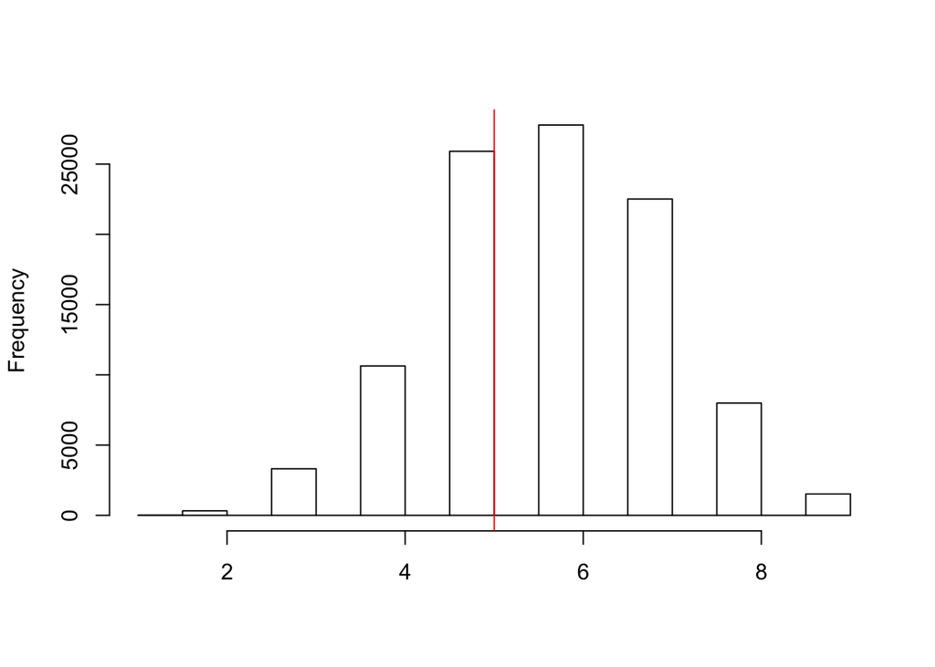

```r
# model 1
y = df$Fatal_accidents

a_star = sum(y) + a
b_star = b + n
thetas = rgamma(size, a_star, b_star)
y_reps = sapply(thetas, rpois, n=n)
num_change = apply(y_reps, 2 , dir_change_count)
num_change0 = dir_change_count(y)

hist(num_change, main=NULL, xlab=NULL)
abline(v=num_change0, col='red')
```

```r
print(sum(num_change<=num_change0)/size)
```

```
## [1] 0.40194
```

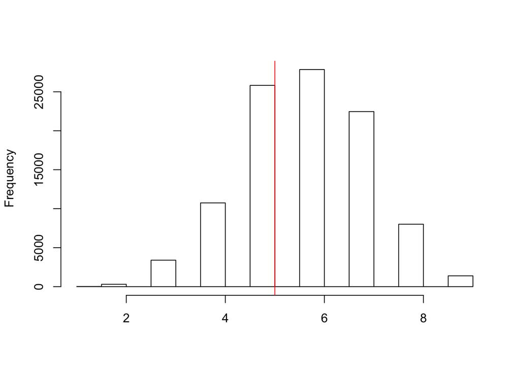

```r
# model 2
a_star = sum(y) + a
b_star = b + sum(c)
thetas = rgamma(size, a_star, b_star)
y_reps = sapply(thetas, rpois, n=n)
num_change = apply(y_reps, 2 , dir_change_count)
num_change0 = dir_change_count(y)

hist(num_change, main=NULL, xlab=NULL)
abline(v=num_change0, col='red')
```

```r
print(sum(num_change<=num_change0)/size)
```

```
## [1] 0.40282
```

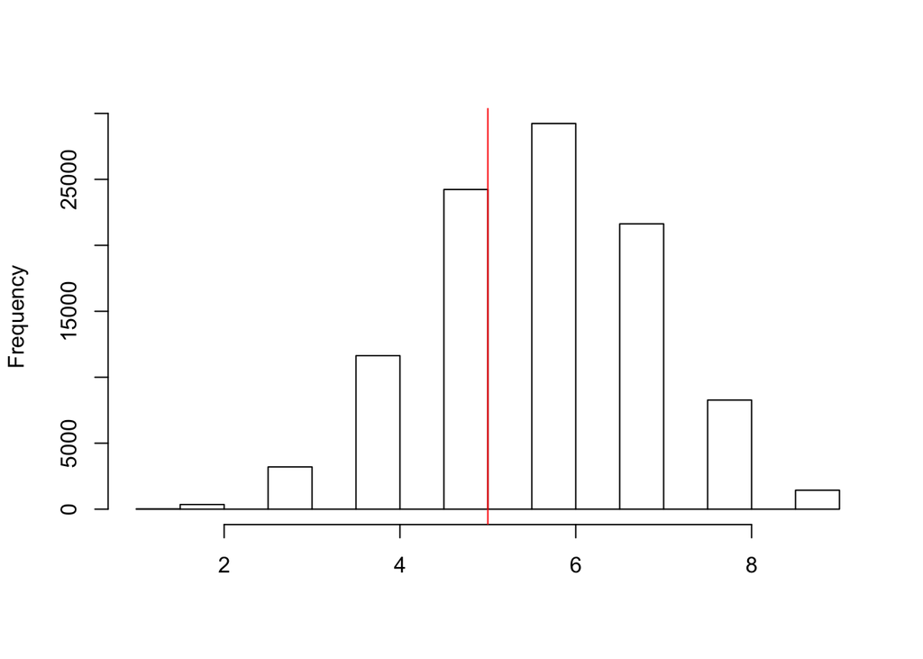

```r
# model 3
y = df$Passenger_deaths
a_star = sum(y) + a
b_star = b + n
thetas = rgamma(size, a_star, b_star)
y_reps = sapply(thetas, rpois, n=n)
num_change = apply(y_reps, 2 , dir_change_count)
num_change0 = dir_change_count(y)

hist(num_change, main=NULL, xlab=NULL)
abline(v=num_change0, col='red')
```

```r
print(sum(num_change<=num_change0)/size)
```

```
## [1] 0.39432
```

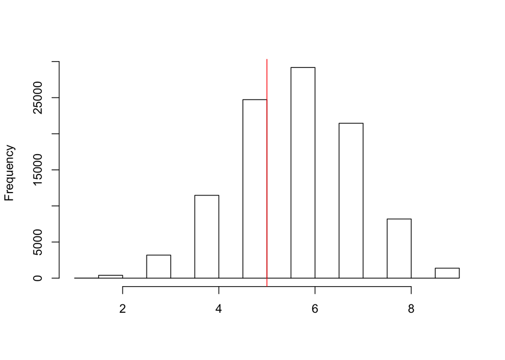

```r
# model 4
a_star = sum(y) + a
b_star = b + sum(c)
thetas = rgamma(size, a_star, b_star)
y_reps = sapply(thetas, rpois, n=n)
num_change = apply(y_reps, 2 , dir_change_count)
num_change0 = dir_change_count(y)

hist(num_change, main=NULL, xlab=NULL)
abline(v=num_change0, col='red')
```

```r
print(sum(num_change<=num_change0)/size)
```

```
## [1] 0.3979
```

2. For each of the models, use simulations from the posterior predivtive distributions to measure the discrepancies. Display the discrepancies graphically and give p-values.
3. Do the results of the posterior predictive checks agree with with your answers in Exercise 2.13(e)?

# 6.7.6

Variety of predictive reference sets: in the example of binary outcomes on page 147, it is assumed that the number of measurements, n, is fixed in advance, and so the hypothetical replications under the binomial model are performed with n = 20. Suppose instead that the protocol for measurement is to stop once 13 zeros have appeared.  
The observation from page 147 is as: 1, 1, 0, 0, 0, 0, 0, 1, 1, 1, 1, 1, 0, 0, 0, 0, 0, 0, 0, 0.

1. Explain why the posterior distribution of the parameter $\theta$ under the assumed model does not change.
   If we say that we stop collecting until we get 13 zeros, then the likelihood function is changed to a negative binomial distribution:
   $$f(y|\theta) = {\Sigma y_i+12\choose{\Sigma y_i}}\theta^{\Sigma y_i}(1-\theta)^{13} \\
   p(\theta) \propto 1 \\
   p(\theta|y) \propto \theta^{\Sigma y_i}(1-\theta)^{13} \\
   \theta|y \sim Beta(8, 14)$$
   Therefore, we still obtain the same posterior distribution.
2. Perform a posterior predictive check, using the same test quantity, T = number of switches, but simulating the replications $y^{rep}$ under the new measurement protocol. Display the predictive simulations, $T(y^{rep})$, and discuss how they differ from Figure 6.5.

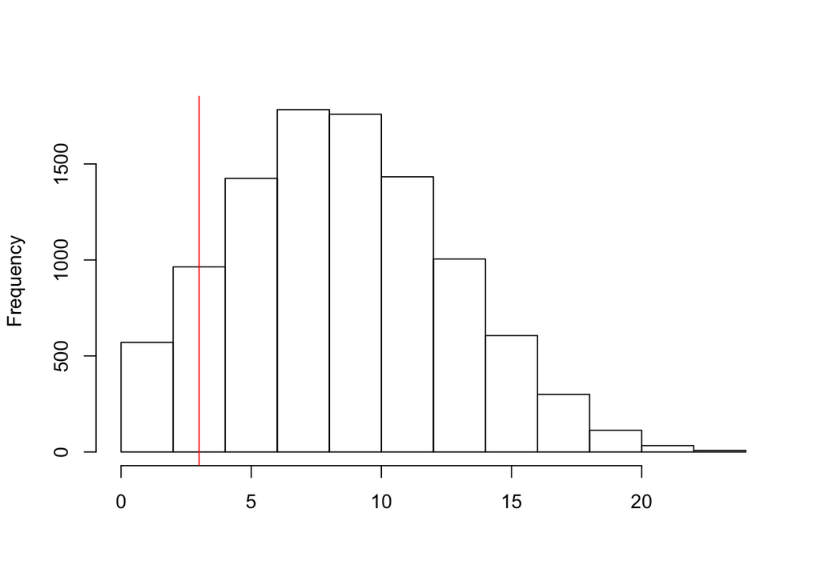

```r
set.seed(3000)
thetas = rbeta(10000, 8, 14) # \theta | y
# yreps = sapply(thetas, FUN = function(X) {rnbinom(1, prob=X, 13)} ) # y | \theta
# hist(yreps, xlab=expression(y^{rep}), main=expression(paste('Histogram of ', y^{rep}) ))

sequence_generator = function(prob, n) {
  seq = rbinom(1, prob=prob, size=1)

  while(sum(seq==0) < n){
    seq = c(seq, rbinom(1,prob=prob, size=1))
  }

  seq
}

switch_count = function(target_sequence){
   count = 0

   for(i in 2:length(target_sequence)){
     cur = target_sequence[i-1]
     nex = target_sequence[i]

     if(cur != nex) count = count + 1
   }

   count
}

num_switch = sapply(thetas, function(x){

  tmp_seq = sequence_generator(x, 13)
  return(switch_count(tmp_seq))

})
hist(num_switch, main=NULL, xlab=NULL)
abline(v=3, col='red')
```

```r
print(sum(num_switch<=3)/10000)
```

```
## [1] 0.0726
```

1. Draw $\theta|y \sim Beta(8,14)$
2. Draw a sequence of $y_i \sim Bernoulli(\theta)$
3. Caculate number of switches
4. Repeat 10000 times

Comparing to the Figure 6.5, two plots are similar with the mean around 7 to 9. Under negative binomial model, the range of the histogram has been extended, it means the simulation under the new protocol has larger variance. And p-value = 0.0726 which is larger than the result returned before. In the new plot, it is obvious, the histogram has heavier right tail.

# 7.8.4

Bayes factors when the prior distribution is improper: on page 183, we discuss Bayes factors for comparing two extreme models for the SAT coaching example.  
(a) Derive the Bayes factor, $\frac{p(H_2|y)}{p(H_1|y)}$, as a function of $y_1,\dots,y_J,\sigma_1,\dots,\sigma_J$, and A, for the models with $N(0,A^2)$ prior distributions.  
(b) Evaluate the Bayes factor in the limit $A \rightarrow \infty$.  
(c) For fixed A, evaluate the Bayes factor as the number of schools J, increases. Assume for simplicity that $\sigma_1=\cdots=\sigma_J=\sigma$, and that the sample mean and variance of the $y_j$’s do not change.

# 7.8.5

# 8.10.11

Capture-recapture: a statistician/fisherman is interested in N, the number of fish in a certain pond. He catches 100 fish, tags them, and throws them back. A few days later, he returns and catches fish until he has caught 20 tagged fish, at which point he has also caught 70 untagged fish. (That is, the second sample has 20 tagged fish out of 90 total.)
(a) Assuming that all fish are sampled independently and with equal probability, give the posterior distribution for N based on a noninformative prior distribution. (You can give the density in unnormalized form.)
$$x|N \sim NegBin(20, \frac{100}{N})\\
p(N) \propto 1 \\
f(x|N) = \binom{x+19}{x}(1-\frac{100}{N})^{20}(\frac{100}{N})^x \\
p(N|x) \propto (1-\frac{100}{N})^{20}(\frac{100}{N})^{x}$$
(b) Briefly discuss your prior distribution and also make sure your posterior distribution is proper.
I just used laplace prior when I don’t have information about N. Let $M = \frac{100}{N}$
$$|J| = \frac{100}{M^2} \\
p(M|x) \propto 100(1-M)^{20}M^{x-2} \propto M^{x-2}(1-M)^{20} \\
M \sim Beta(x-2, 20)$$
Then the posterior distribution is a proper distribution.

(c) Give the probability that the next fish caught by the fisherman is tagged. Write the result as a sum or integral - you do not need to evaluate it, the the result should not be a function of N.

(d) THe statistician/fisherman checks his second catch of fish and realizes that, of the 20 ‘tagged’ fish, 15 are definitely tagged, but the other 5 may be tagged - he is not sure. Include this aspect of missing data in your model and give the new joint posterior density for all parameters (in unnormalized form).

# 8.10.14

Rounded data: the last two columns of passenger airline deaths and deaths per passenger mile flown. We would like to divide these to obtain the number of passenger miles flown in each year, but the ‘per mile’ data are rounded.

```r
kable(df[,c(1,3,4)], col.names = c("Year", "Passenger Deaths", "Death Rate"))
```

| Year | Passenger Deaths | Death Rate |
| --- | --- | --- |
| 1976 | 734 | 0.19 |
| 1977 | 516 | 0.12 |
| 1978 | 754 | 0.15 |
| 1979 | 877 | 0.16 |
| 1980 | 814 | 0.14 |
| 1981 | 362 | 0.06 |
| 1982 | 764 | 0.13 |
| 1983 | 809 | 0.13 |
| 1984 | 223 | 0.03 |
| 1985 | 1066 | 0.15 |

```r
num_pml = df$Passenger_deaths / df$Death_rate
```

(a) Using just the data from 1976, obtain inference for the number of passenger miles flown in 1976. Give a 95% posterior interval (you may do this by simulation). Clearly specify your model and your prior distribution.
$$\begin{aligned}
y_i | \theta &\sim poi(\theta) \\
\theta &\sim Gamma(a, b) \\
\theta|y &\sim Gamma(\Sigma y_i + a, b+n)
\end{aligned}$$

```r
a_star = num_pml[1]
```

# Extra 1

For each of the examples considered in class regarding the censored and truncated weights data develop an approach based on MCMC with auxiliary variables and write the full conditionals.

censored data with known censoring point.
$$\begin{aligned}
\theta | y_{obs}, y_{mis} &\sim N(\theta| (\frac{\Sigma y_{obs}+\Sigma y_{mis}}{100}), \frac{1}{100}) \\
y_{mis}| \theta &\sim N(y_{mis}|\theta, 1)I_{y_{mis} \ge 200}
\end{aligned}$$
We bring $y_{mis}$ as a latent variable, since it cannot be observed. And We know that $y_{mis}$ also following a truncated normal distribution with mean $\theta$ and variance 1 truncated at 200.

truncated data with known truncation point
$$\begin{aligned}
p(\theta|y_{obs},I) \propto p(\theta)N(\theta|\bar{y}_{obs}, \frac{1}{91})\Sigma_{91}^{\infty}p(N|\theta)\binom{N}{91}[\Phi(\theta-200)]^{N-91}
\end{aligned}$$

# Extra 2

We use non-informative prior $p(\theta, \sigma) \propto 1$. Therefore we obtain the following posterior distribution.

```r
set.seed(10)
library(mvtnorm)
# Metropolis Hasting
theta_cur = 65
sigma2_cur = 2
size = 10000

eval_ratio = function(theta_1, sigma2_1, theta_2, sigma2_2){
  # evaluating the likelihood
  data = c(14,30,49,70,33,15)
  bs = seq(66,74,by=2) # bounds

  qs1 = pnorm((bs-theta_1)/sqrt(sigma2_1),0,1) # cdf of standard normal
  diffs1 = diff(qs1) # difference between cdfs
  ps1 = c(qs1[1], diffs1, 1-qs1[5]) # p1,...,p6

  qs2 = pnorm((bs-theta_2)/sqrt(sigma2_2),0,1) # cdf of standard normal
  diffs2 = diff(qs2) # difference between cdfs
  ps2 = c(qs2[1], diffs2, 1-qs2[5]) # p1,...,p6


  log_val = data*(log(ps2)- log(ps1))# log-scale likelihood

  sum(log_val)
}

thetas = rep(NA, size)
sigma2s = rep(NA, size)
for(i in 1:size){
  # random walk MH

  noises = rmvnorm(1, mean=c(0,0), sigma=0.1*diag(2))
  theta_prop = theta_cur + noises[1,1]
  sigma2_prop = (sqrt(sigma2_cur)+noises[1,2])^2

  #ratio = eval_qfunc(theta_prop, sigma2_prop) - eval_qfunc(theta_cur, sigma2_cur)
  ratio = eval_ratio(theta_cur, sigma2_cur, theta_prop, sigma2_prop)

  if(ratio > log(runif(1))){
    theta_cur = theta_prop
    sigma2_cur = sigma2_prop
  }
  thetas[i] = theta_cur
  sigma2s[i] = sigma2_cur
}
```

Take burnin size 5000

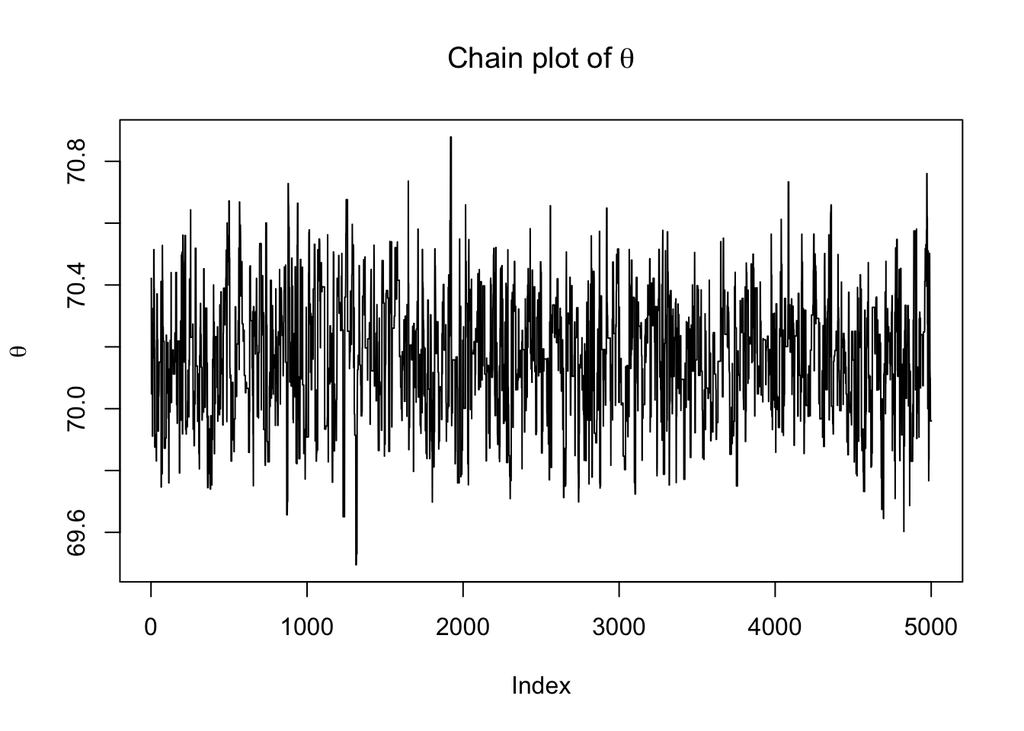

```r
burnin=5000
plot(thetas[burnin:size], type='l', main=expression(paste('Chain plot of ', theta)), ylab=expression(theta))
```

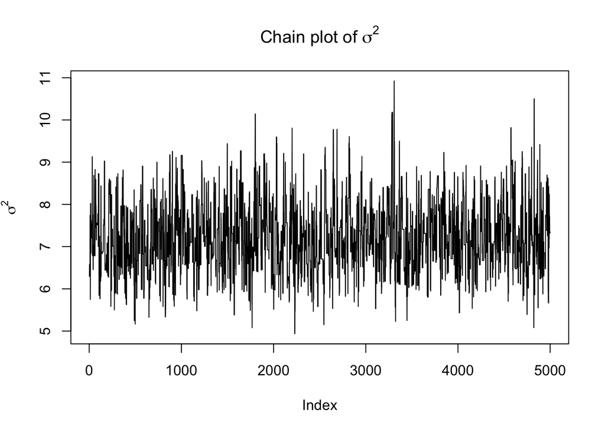

```r
plot(sigma2s[burnin:size], type='l', main=expression(paste('Chain plot of ', sigma^2)), ylab=expression(sigma^2))
```

(2) Introduce latent variables and use Gibbs sampling to do the estimation. Compare.  
Now we bring in a latent variable, $z$, where $z_i\sim N(\theta, \sigma^2)I_{(b_i<z<b_{i+1})}$. We use the truncated normal distributions.

$$f(x_i|z) = \Sigma_j I_{z_j \in \text{(ith interval)}}\\
z_j|\theta, \sigma^2 \sim N(\theta, \sigma^2) \\
p(\theta, \sigma^2) \propto 1 \\
f(z|\theta, \sigma^2) = (\frac{1}{\sqrt{2\pi \sigma^2}})^n exp\{-\frac{\Sigma(z_i-\theta)^2}{2\sigma^2} \} \\
f(x|z) = \Pi_i(\Sigma_j I_{z_j\in \text{(ith interval)}}) \\
p(z,\theta, \sigma^2|x) \propto (\frac{1}{\sqrt{2\pi \sigma^2}})^n exp\{-\frac{\Sigma(z_i-\theta)^2}{2\sigma^2} \}\Pi_i(\Sigma_j I_{z_j\in \text{(ith interval)}})$$

```r
rtruncnorm = function(n, theta, sigma2, x1, x2){
  cdf_grids = runif(n)
  phib = pnorm(x2, mean=theta, sd=sqrt(sigma2))
  phia = pnorm(x1, mean=theta, sd=sqrt(sigma2))

  qs = sapply(cdf_grids, function(x) (x*(phib-phia) + phia))
  zs = sapply(qs, qnorm, mean = theta, sd = sqrt(sigma2))
  zs
}

set.seed(10)
# Gibbs on latant variable
xs = c(14,30,49,70,33,15)
n = sum(xs)
theta_cur = 70
sigma2_cur = 10

cutpoints = c(-Inf,66,68,70,72,74,Inf)

# initialization
size = 10000
thetas = rep(NA, size)
sigma2s = rep(NA, size)
zs = matrix(NA, ncol=n, nrow=size)

for(i in 1:size){
  z_cur = NULL
  for(j in 1:6){
    z_cur = c(z_cur, rtruncnorm(
      n=xs[j],
      theta=theta_cur,
      sigma2=sigma2_cur,
      x1=cutpoints[j],
      x2=cutpoints[j+1])
      )
  }
  theta_cur = rnorm(1, mean(z_cur), sd=sqrt(sigma2_cur)/n)

  sigma2_cur = rigamma(1, n/2-1, sum((z_cur - theta_cur)^2)/2)

  # saving simulations
  thetas[i] = theta_cur
  sigma2s[i] = sigma2_cur
  zs[i,] = z_cur
}
```

Show the chain plots

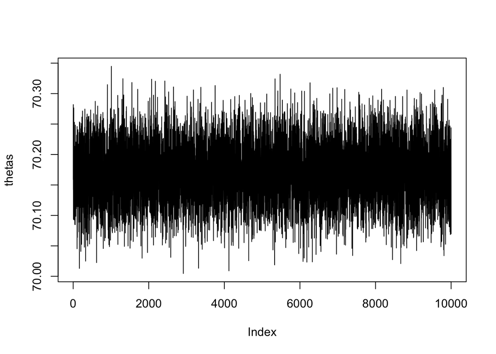

```r
plot(thetas, type='l')
```

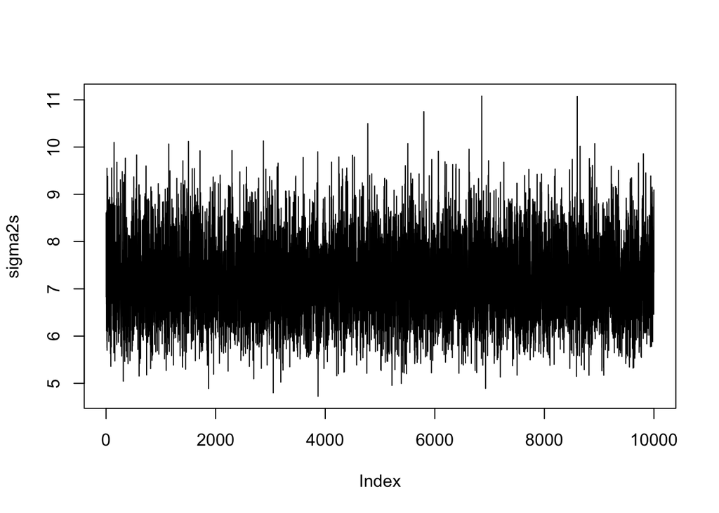

```r
plot(sigma2s, type='l')
```

# Extra 3

# Extra 4

Show that the posterior predictive distribution of a new observation corresponding to a regression model is a student distribution as indicated in the slides.

# Extra 5

Consider the data available as “birthweight” form the package “LearnBayes”. Fit a linear regression that considers age and gender as explanatory variables for birth weight. Describe the posterior distribution of the regression parameters using a sample-based approach. Explore the predictive posterior distribution for the birth weight of children in the following four cases: (a) 36 week female/male; (b) 40 week female/male. Compare.

```r
kable(birthweight)
```

| age | gender | weight |
| --- | --- | --- |
| 40 | 0 | 2968 |
| 38 | 0 | 2795 |
| 40 | 0 | 3163 |
| 35 | 0 | 2925 |
| 36 | 0 | 2625 |
| 37 | 0 | 2847 |
| 41 | 0 | 3292 |
| 40 | 0 | 3473 |
| 37 | 0 | 2628 |
| 38 | 0 | 3176 |
| 40 | 0 | 3421 |
| 38 | 0 | 2975 |
| 40 | 1 | 3317 |
| 36 | 1 | 2729 |
| 40 | 1 | 2935 |
| 38 | 1 | 2754 |
| 42 | 1 | 3210 |
| 39 | 1 | 2817 |
| 36 | 1 | 3126 |
| 37 | 1 | 2539 |
| 36 | 1 | 2412 |
| 38 | 1 | 2991 |
| 39 | 1 | 2875 |
| 40 | 1 | 3231 |